# esm_206_lab_5

Amy Anderson

10/28/2019

## Objectives:

- Getting counts for different groups
- Use {lubridate} to parse dates
- Find confidence intervals & do t-tests with t.test()
- Heatmap with geom_tile()

#### read in lobster data

```r
lobster_abundance <- read_csv(here::here("data", "lobster_abundance.csv"),
                              na = "-99999") %>% # automatically replaces the na placeholder in this data frame with NA instead
  clean_names() # take variable names out of CAPSLOCK and into snake_case
```

This table is a frequency table. Tidy format data is in case format, which eliminates the need to weight other stats by the count of each variable in a frequency table.

First, expand the amounts in the ‘count’ column using the uncount() function in tidyr

```r
lobster_tidy <- lobster_abundance %>%
  tidyr::uncount(lobster_count)
```

Now each lobster (i.e., each observation) has its own row. Tidy!!

Let’s look at this some different ways:

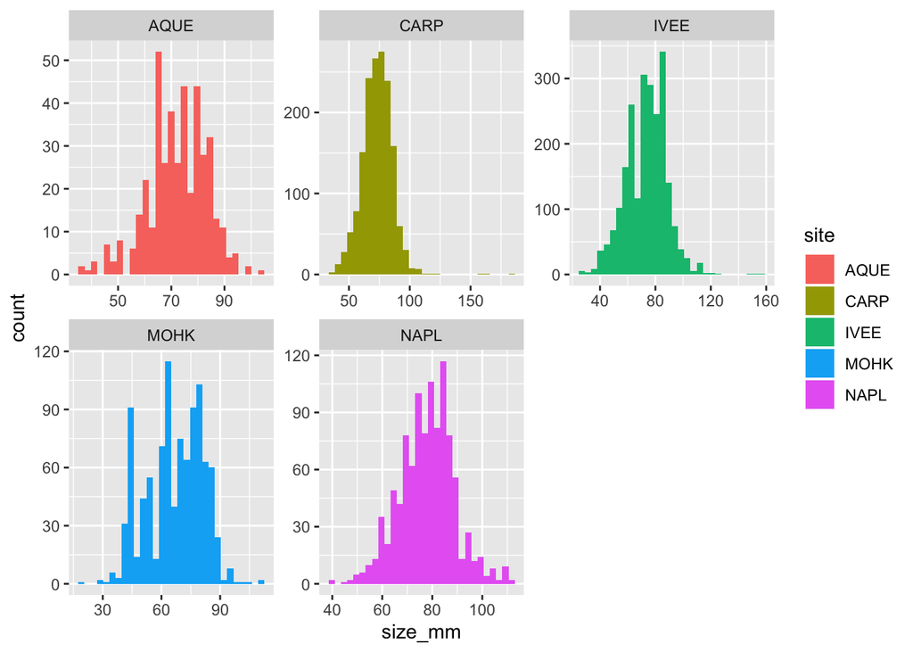

```r
#View(lobster_tidy)

# Jitter plot of lobster size for each different site
# ggplot(data = lobster_tidy, aes(x = site)) +
  # geom_jitter()

ggplot(data = lobster_tidy, aes(x = size_mm)) +
  geom_histogram(aes(fill = site)) +
  facet_wrap(~site, scales = "free") # THIS IS IMPORTANT
```

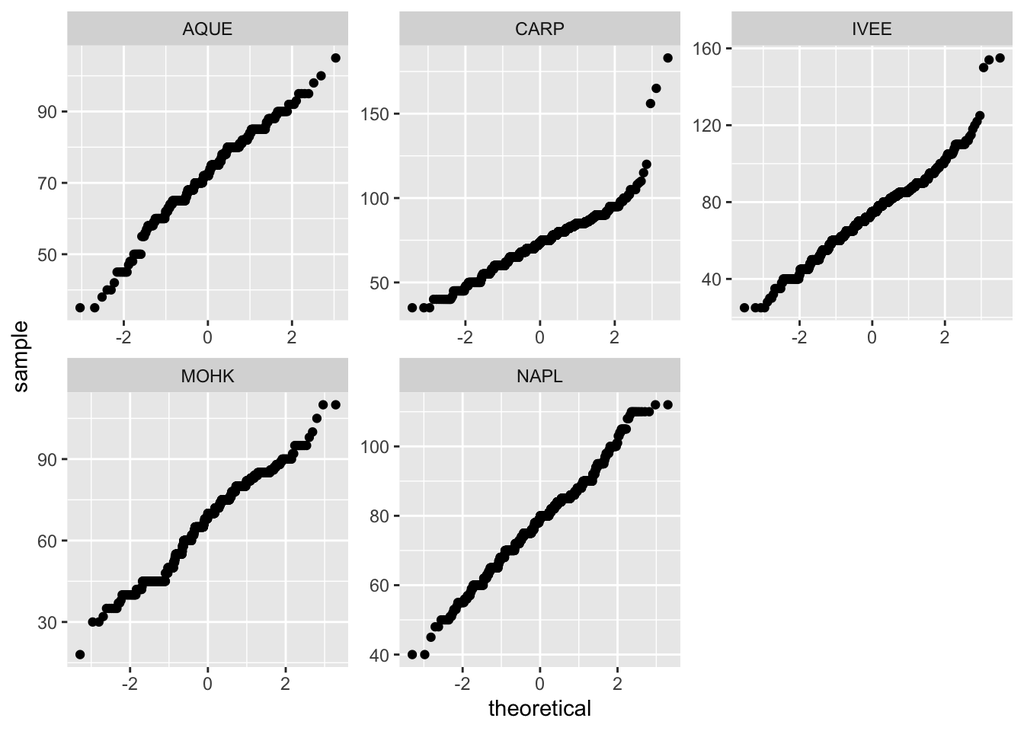

```r
# make a Q-Q plot to check normality of lobster size data
ggplot(data = lobster_tidy, aes(sample = size_mm)) +
  geom_qq() +
facet_wrap(~site, scales = "free")
```

The date is currently stored as a character. Here we use {lubridate} to change that.

I’m going to add a new column with ‘mutate()’ that contains my date as an actual date

```r
lobster_date <- lobster_tidy %>%
  mutate(
    date_new = lubridate::mdy(date)
  )
```

Now parse the ‘Date’ column to get the different pieces (month, year) separated

```r
lobster_parse_date <- lobster_date %>%
  mutate(
    obs_month = lubridate::month(date_new, label = TRUE), # the 'month' argument pulls out the month from the full date, and the 'label' argument writes in month names rather than month numbers
    obs_year = lubridate::year(date_new)
  )
```

Count lobsters by different groupings….

Starting with number of lobsters by year and month

```r
lobster_ym <- lobster_parse_date %>%
  count(obs_year, obs_month) # count is great for categorical data in tidy format


lobster_ysite <- lobster_parse_date %>%
  count(obs_year, site)

lobster_totsite <- lobster_parse_date %>%
  count(site)



# group_by + summarize + n()
lobster_summary <- lobster_parse_date %>%
  group_by(site) %>%
  summarize(
    mean_size = mean(size_mm, na.rm = TRUE),
    sd_size = sd(size_mm, na.rm = TRUE),
    sample_n = n()
  )
```

Confidence intervals and t-tests:

Use the ‘t.test()’ function to find confidence intervals and perform t-tests

```r
ivee_lobsters <- lobster_tidy %>%
  filter(site == "IVEE") %>%
pull(size_mm) # the 'pull()' command creates a vector, which is useful for some operations. Using 'select()' creates a tbl_df with a single column.


t.test(ivee_lobsters)
```

```
##
##  One Sample t-test
##
## data:  ivee_lobsters
## t = 245.23, df = 2302, p-value < 2.2e-16
## alternative hypothesis: true mean is not equal to 0
## 95 percent confidence interval:
##  72.99130 74.16806
## sample estimates:
## mean of x
##  73.57968
```

Two-sample t-tests: Is there a significant difference in mean lobster lengths between Naples reef and Mohawk reef?

```r
napl_sample <- lobster_tidy %>%
  filter(site == "NAPL") %>%
  pull(size_mm)

mohk_sample <- lobster_tidy %>%
  filter(site == "MOHK") %>%
  pull(size_mm)


mohk_napl_ttest <- t.test(napl_sample, mohk_sample)
mohk_napl_ttest
```

```
##
##  Welch Two Sample t-test
##
## data:  napl_sample and mohk_sample
## t = 19.849, df = 1850.8, p-value < 2.2e-16
## alternative hypothesis: true difference in means is not equal to 0
## 95 percent confidence interval:
##  10.19806 12.43436
## sample estimates:
## mean of x mean of y
##  78.18454  66.86833
```

Mean lobster size differed significantly between Mohawk and Naples reefs (t(1850.7720862))

Maybe an easier way….

```r
lobster_2sample <- lobster_tidy %>%
  filter(site %in% c("NAPL", "MOHK"))

ttest_2 <- t.test(size_mm ~ site, data = lobster_2sample) # careful though, this only works if your data contains only two groups

ttest_2 #same results as napl_mohk_ttest
```

```
##
##  Welch Two Sample t-test
##
## data:  size_mm by site
## t = -19.849, df = 1850.8, p-value < 2.2e-16
## alternative hypothesis: true difference in means is not equal to 0
## 95 percent confidence interval:
##  -12.43436 -10.19806
## sample estimates:
## mean in group MOHK mean in group NAPL
##           66.86833           78.18454
```

Now let’s make a geom_tile() heatmap

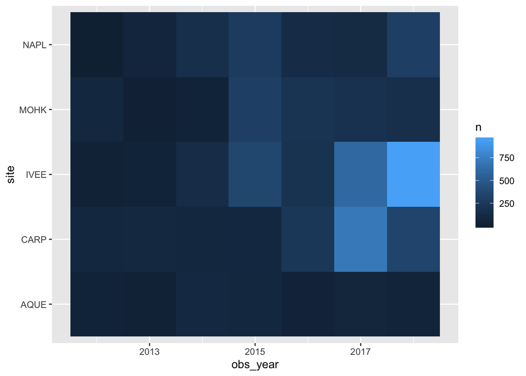

```r
ggplot(data = lobster_ysite, aes(x = obs_year, y = site)) +
  geom_tile(aes(fill = n))
```